# Análisis de microarrays *Clariom D Human* en R

# 3 Generar fotos de los microarrays

A partir de la matriz de intensidades del microarray, podemos reconstruir su apariencia original con las siguientes líneas de código:

```r
# Generamos paleta de colores verde -> amarillo -> rojo
colores_hibridacion <- rev(RColorBrewer::brewer.pal(n = 11, name = "RdYlGn"))

# Establecemos temporalmente la carpeta de trabajo en "imagenes_microarrays"
setwd("./Fotos arrays Clariom D Human/")

# Reconstruimos la apariencia original de los microarrays hibridados y guardamos
# las imágenes resultantes con resolución 720p en la carpeta
# "imagenes_microarrays"
for (i in pData(datos_crudos_microarrays)$muestra) {
  nombre.imagen = paste(sampleNames(datos_crudos_microarrays)[i],".png",sep="")
  png(filename = nombre.imagen, width = 1280, height = 720, units = "px", bg = "black")
  image(x = datos_crudos_microarrays[,i], col = colores_hibridacion)
  dev.off()
}

# Reestablecemos la carpeta de trabajo original
setwd("./")
```

Las fotos reconstruidas se encuentran en la carpeta `Fotos arrays Clariom D Human`.

**Click para ver imagen**

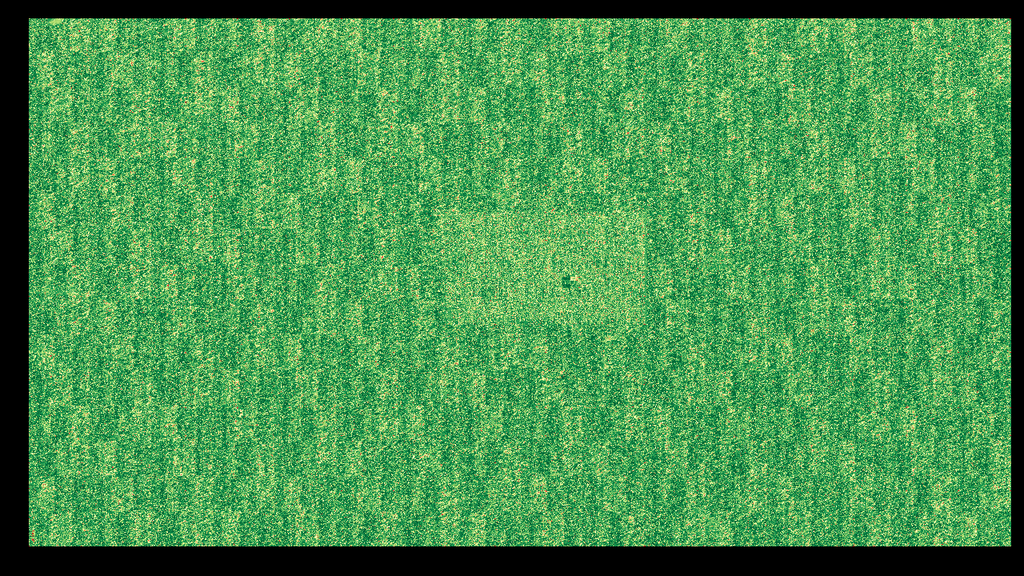

Muestra control nº1

# 4 Bibliografía

- Butler, A., Hoffman, P., Smibert, P. et al. Integrating single-cell transcriptomic data across different conditions, technologies, and species. Nat Biotechnol 36, 411–420 (2018). https://doi.org/10.1038/nbt.4096
- Nakamura, T., Okamoto, I., Sasaki, K., Yabuta, Y., Iwatani, C., Tsuchiya, H., Seita, Y., Nakamura, S., Yamamoto, T., and Saitou, M. (2016). A developmental coordinate of pluripotency among mice, monkeys and humans. Nature, 537(7618):57–62

# 5 sessionInfo()